# Causal Inference: Milestone2

Author

Na Nguyen and Charles Batsaikhan

# Introduction

In the 1920s, Minneapolis introduced racial covenants to prevent non-white people from occupying and owning land. As Minnesota witnessed the wave of the First Great Migration, it also legitimized housing discrimination via restrictive clauses inserted into property documents since the presence of non-White, but especially Black people, was regarded to decrease property value. This racist real estate practice paved the way to redlining in the 1940s to decrease homeownership rates of African American, contributing to their generational dispossession and displacement. (Source, Source)

While white areas were endorsed with beautification projects and accessible green spaces, Black residents saw their neighborhoods surrounded with highways, factories, and overall exposure to hazard. And the legacy of residential segregation has led to stark environmental injustice that tremendously ails Black, Latino, and Native American families in Minneapolis:

- 6x asthma death risk
  - Among those who were under age 65, the asthma death rate for Black Minnesotans was 6 times higher than it was for white Minnesotans.
- 3x higher infant mortality
  - Infant mortality rate for Native Americans is nearly 3x higher than that of white Minnesotans.
- 9x positive COVID-19 tests
  - Latinx Minnesotans are testing positive at more than 4 times the overall population and 9 times the white population.
- Over 2x the cancer risk
- Black Minnesotans have 2.25 times the cancer risk as the average Minnesotan (Source)

There has been extensive research that definitively proves disproportionate pollution linked to geographically disadvantaged and vulnerable communities. However, these research tend to merely provide a snapshot of this picture at a moment in time. Therefore, we would like to contextualize these single portraits of inequality by investigating the relationship between modern day environmental inequality in Minneapolis and 1920’s racial covenants practice.

The research question we would like to explore is as follows: Looking at historically racially covenanted neighborhoods in Minneapolis and present day environmental data, can we still see its impact in the disparity of climate change effects? In other words, *did the introduction of racial covenants in the 1920s cause air pollution inequality in the city of Minneapolis that we see today?*

# Data

## Data Exploration

In this boxplot, we can observe that between the socially vulnerable (Treated) and non-socially vulnerable (Control) groups, the median for air pollution is higher for the treated group by 0.3 tons of PM2.5 emissions.

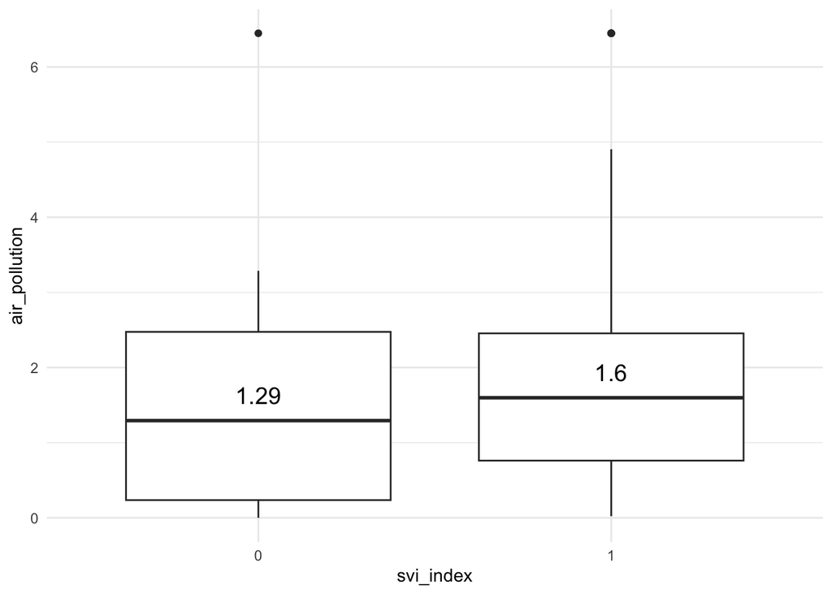

# Methods

Moving forward, we will work with the following variables at the census tract level in the city of Minneapolis:

- `has_racial_covenants`: whether or not a census tract previously had a racial covenant on its property
- `holc_grade`: the census tract’s Home Owner Loan Corporation (HOLC) neighborhood grades: A, B, C, or D (corresponding to A = “Best”; B = “Still Desirable”; C = “Declining”; and D = “Hazardous” designations, respectively)
- `svi_index`: whether or not a census tract is considered as socially vulnerable by the CDC
- `tree_canopy`: the percentage of tree canopy area of a census tract.
- `air_pollution`: the emission (tons) of PM2.5 from permitted facilities/factories in a census tract.

**Note: A handful of census tracts do not have a `holc_grade` because they reside in downtown business areas of Minneapolis, not residential areas**

## Our Causal DAG

According to our DAG, our control set includes the following variables: `holc_grade`, and `tree_canopy`

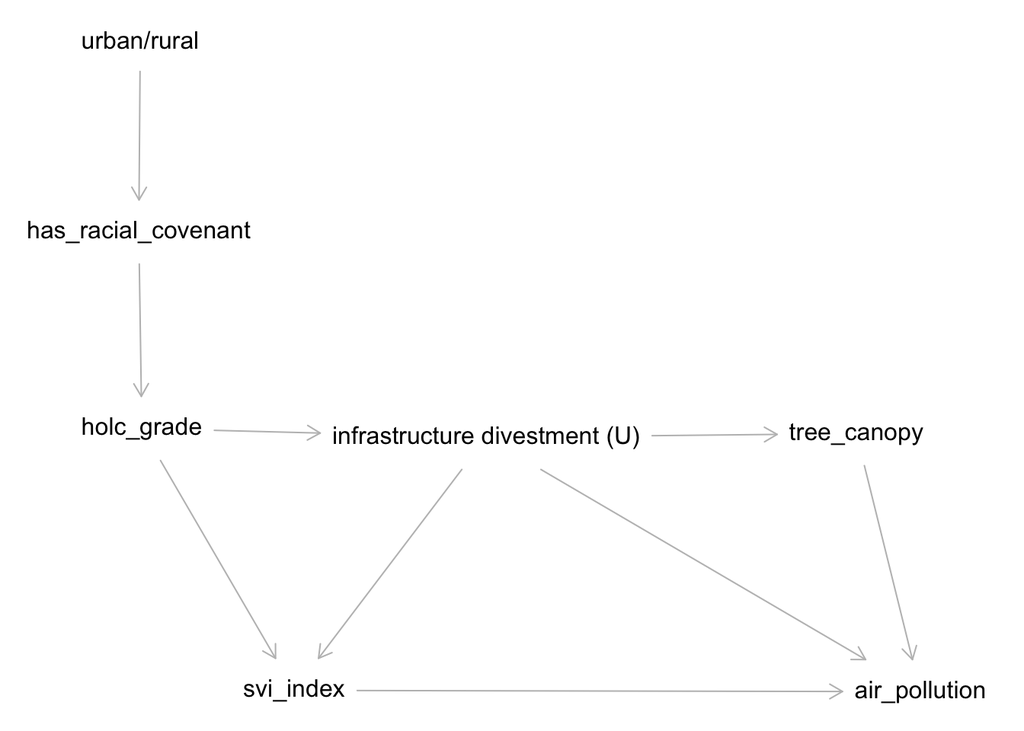

## Matching

- Standard Mean Difference for all `holc_grade`’s are well within the 0-0.1 threshold.
- Yielding a large enough matched sample size.

In the end, we opted for the Exact Matching Method. As opposed to other methods that resulted in rather large Standard Mean Differences ( >= 0.4), Exact Matching will keep our SMD at the minimum (0). However, because there are a handful of census tracts that do **not** have a `holc_grade`, our final matched sample size for treated is smaller: 19 untreated and 72 treated. The limited sample size may affect the generalizability of the results, so the findings should be interpreted with caution, and future studies with larger sample sizes would be needed to validate the conclusions.

Nonetheless, this method is the most optimal as it helps us to be confident in our later estimates for the causal relationship between our outcome and treatment variables.

## Estimate Results

```
 Estimate Std. Error    z Pr(>|z|)   S  2.5 % 97.5 %
    0.967      0.448 2.16   0.0308 5.0 0.0896   1.84

Term: svi_index
Type:  response
Comparison: mean(1) - mean(0)
Columns: term, contrast, estimate, std.error, statistic, p.value, s.value, conf.low, conf.high, predicted_lo, predicted_hi, predicted
```

## Sensitivity Analysis

```
            point    lower    upper
RR       1.686731 1.050253 2.708929
E-values 2.762989 1.279989       NA
```

If the estimate of the causal effect is 0.967, social vulnerability would have to be 2.76 times more common in census tracts with infrastructure divestment than those that don’t.

If the estimate of the causal effect is 0.967, infrastructure divestment would have to be 2.76 times more common in census tracts with high pollution areas than those that don’t.

# Code

Full Matching

```r
match_out_full <- matchit(
    svi_index ~ holc_grade,
    data = final,
    method = "full",
    distance = "glm",
    estimand = "ATE"
)

match_out_full_summ <- summary(match_out_full, interactions = TRUE)

plot(match_out_full_summ)
```

Subclass matching

```r
match_out_subclass <- matchit(
    svi_index ~ holc_grade,
    data = final,
    method = "subclass",
    subclass = 5,
    distance = "glm",
    estimand = "ATT"
)

# Compute balance statistics overall across all subclasses
match_out_subclass_summ <- summary(match_out_subclass, interactions = TRUE)
plot(match_out_subclass_summ)
```

Coarsened Exact Matching

```r
match_out_cem <- matchit(
    svi_index ~ holc_grade,
    data = final,
    method = "cem",
    distance = NULL,
    estimand = "ATE"
)

match_out_cem_summ <- summary(match_out_exact, interactions = TRUE, un = FALSE)
match_out_cem_summ
```

Exact Matching

```r
match_out_exact <- matchit(
    svi_index ~ holc_grade,
    data = final,
    method = "exact",
    distance = NULL,
    estimand = "ATE"
)

match_out_exact_summ <- summary(match_out_exact, interactions = TRUE, un = FALSE)
match_out_exact_summ
```

Estimates

```r
mod <- lm(air_pollution ~ svi_index*tree_canopy_area, data = match_out_exact, weights = weights)

avg_comparisons(
    mod,
    variables = "svi_index",
    vcov = ~subclass,
    newdata = match_out_exact
)
```

Evalues

```r
evalues.OLS(est= 0.967, se=0.448, sd=sd(match_out_exact$air_pollution))
```